# Heterogeneous agent models

The [Github repo](https://github.com/shokru/macro_course) of the first part of the course contains the html and Quarto notebooks for the code. All the academic references (paper) and many others can be accessed in the following [zip file](https://drive.google.com/file/d/1E4apPYSXvyjRF1Kqr9is-50gs4lW5bv5/view?usp=drive_link).

**NOTE**: The present notebook is coded in R. It relies heavily on the [**tidyverse**](https://www.tidyverse.org/) ecosystem of packages. We load the tidyverse below as a prerequisite for the rest of the notebook - along with a few other libraries.

$\rightarrow$ Don’t forget that code flows **sequentially**. A random chunk may not work if the previous have have not been executed.

```r
library(tidyverse)   # Package for data wrangling
library(readxl)      # Package to import MS Excel files
library(latex2exp)   # Package for LaTeX expressions
library(quantmod)    # Package for stock data extraction
library(highcharter) # Package for reactive plots
library(mvtnorm)     # Package for multivariate gaussian variables
library(broom)       # For regression output
```

# 1 Context

## 1.1 The limits of representative agent models

Many (many) models in economics rely on one unique, rational, **representative agent**. The benefit of a single agent is obvious: such models are much more **tractable** analytically. Indeed, models in science are torn between the tradeoff between simplistic representations of reality which are easier to understand, but often paint a coarse picture of reality and, on the other hand, sophisticated models that match reality better but are harder to grasp and often require long computations.

| Simple model | Complex model |
| --- | --- |
| Closed forms results | Requires simulations / calibration |
| Easy to understand / interpret | Can be hard to comprehend |
| Simplistic / imperfect representation | More accurate, fits data better |

As the authors of [Can a Representative-Agent Model Represent a Heterogeneous-Agent Economy](https://www.aeaweb.org/articles?id=10.1257/mac.1.2.29) put it: “*outcomes of a heterogeneous-agent economy are not readily represented by an optimum of a representative-agent model with stable preferences.*”

# 2 An evolutionary model

In what follows, agents are only interested in maximizing utility over wealth, not consumption. The adjective *evolutionary* comes from the fact that one interesting question pertains to which agent have the best strategy and thus survive in the long run (or upon equilibrium). There is thus some **selection** that operates in the market, akin to the ideas of Darwin.

## 2.1 Framework

This part of the course is based on Section 4.2 of the chapter [Heterogeneous Agent Models in Finance](https://www.sciencedirect.com/science/article/abs/pii/S157400211830008X) (with small changes).

### 2.1.1 The market

Time is discrete $t=1,2,...$. There are $H$ agents types, indexed by $h$ in the market who can trade on $N$ risky assets (henceforth indexed by $n$), as well as on one riskless asset with gross return $R_f=1+r_f$. We write $\textbf{p}_t=(p_{t,1},\dots,p_{t,N})'$ for the vector of time-$t$ prices and similarly $\textbf{d}_t$ and $\textbf{x}_t=\textbf{p}_t+\textbf{d}_t$ for the vectors of dividends and payoffs.

Upon time $t$, the agents do not know $\textbf{p}_t$ (to be determined), but do know $\textbf{d}_t$ (small technical point, not very important).

Vector and matrices are denoted with **bold** letters and $\textbf{v}'$ is the transpose of $\textbf{v}$. $\textbf{1}_N$ is the $N$-dimensional vector of ones and $\textbf{I}_N$ the identity matrix.

There are in total $I$ agents in the market with $I_{t,h}$ of them belonging to group $h$ at time $t$. We write $n_{t,h}=I_{t,h}/I$ for the corresponding proportion of agents in group $h$.

For simplicity, *all* agents have **CARA preferences** over wealth,[^1] i.e., the utility has the form $u_h(w)=-e^{-\theta_hw}$, where $\theta_h$ is each agents own risk aversion level. We write $\textbf{z}_{t,h}$ for the composition (in terms of the number of shares) of the risky component of the portfolio of agent $h$. Hence, agent $h$ invests the remainder of her wealth, $W_{t,h}-\textbf{z}_{t,h}'\textbf{p}_t,$ in the riskless asset. The **wealth dynamics** can then be described by
$$W_{t+1,h}=\textbf{z}_{t,h}'\textbf{x}_{t+1}+(W_{t,h}-\textbf{z}_{t,h}'\textbf{p}_t)R_f. \tag{1}$$

If we assume that the wealth of agents is normally distributed,[^2] we the agents maximize the **quadratic function** of their wealth:
$$U_{t,h}(W_{t+1,h})=\mathbb{E}_{t,h}[W_{t+1,h}]-\frac{\theta_h}{2}\mathbb{V}[W_{t+1,h}]$$

Here, $\mathbb{E}_{t,h}[\cdot]$ is the expectation operator, conditional on the information available at time time, and based on the beliefs of agent $h$. Hence, the model assumes similar preferences for agents, but different beliefs. This is where **heterogeneity** kicks in.

**Side note**

The simplification for the agent’s preferences comes from the moment generating function of the Gaussian law: $\mathbb{E}[-e^{-\theta X}]=-e^{-\mu \theta + (\theta\sigma)^2/2}$. Maximizing this or $\mu \theta - (\theta\sigma)^2/2$ is the same.

Hence, the utility-maximizing composition is

$$\textbf{z}_{t,h}^*=\theta_{h}^{-1}\boldsymbol{\Omega}_{t,h}^{-1}(\mathbb{E}_{t,h}[\textbf{x}_{t+1}]-R_f \textbf{p}_t),$$
where $\boldsymbol{\Omega}_{t,h}$ is agent $h$’s conditional covariance matrix for future payoffs ($\textbf{x}_{t+1}$).

**Proof**

From Equation 1, we have that $\mathbb{E}_{t,h}[W_{t+1}]=\textbf{z}_t'(\mathbb{E}_{t,h}[\textbf{x}_{t+1}]-R_f\textbf{p}_t)+R_fW_t$ and, conditionally at time $t$, only $\textbf{x}_{t+1}$ is random, hence $\mathbb{V}_t[W_{t+1}]=\textbf{z}_t'\boldsymbol{\Omega}_{t}\textbf{z}_t.$ The **first order condition** is then
$$\frac{\partial U_t}{\partial \textbf{z}_t}=(\mathbb{E}_{t,h}[\textbf{x}_{t+1}]-R_f\textbf{p}_t)-\theta \textbf{z}_t \boldsymbol{\Omega}_{t},$$
from which the result follows.

### 2.1.2 The equilibrium

Equilibrium for prices requires a **supply side**. Indeed, our model focuses on the **demand**. We set a vector of fixed demand $\textbf{s}$ and a random **supply shock** $\boldsymbol{\xi}_t$. An alternative way to see this is to consider that there is an alternative class of agents who trade for reasons orthogonal to what we have exposed until now. They act as market makers.

The equilibrium equates total demand and total supply:

$$\sum_{h=1}^H n_{t,h} \theta_{h}^{-1}\boldsymbol{\Omega}_{t,h}^{-1}(\mathbb{E}_{t,h}[\textbf{x}_{t+1}]-R_f \textbf{p}_t) =\textbf{s}+ \boldsymbol{\xi}_t .$$

This can be solved to extract the vector of prices:

$$\textbf{p}_t= R_f^{-1} \left(\mathbb{E}_{t,c}[\textbf{x}_{t+1}]-\theta_{t,c} \boldsymbol{\Omega}_{t,c} (\textbf{s}+ \boldsymbol{\xi}_t)\right),$$
where

$$\mathbb{E}_{t,c}[\textbf{x}_{t+1}]=\theta_{t,c}\boldsymbol{\Omega}_{t,c}\sum_{h=1}^Hn_{t,h} \theta^{-1}_h\boldsymbol{\Omega}_{t,h}^{-1} \mathbb{E}_{t,h}[\textbf{x}_{t+1}]$$

is the **consensus** expectation for future payoffs (mind the scaling factors that ensure homogeneity) and

$$\boldsymbol{\Omega}_{t,c} = \theta_{t,c}^{-1}\left(\sum_{h=1}^H n_{t,h}\theta_{h}^{-1}\boldsymbol{\Omega}_{t,h}^{-1} \right)^{-1}$$
can be thought of a time-$t$ **consensus** covariance matrix. Likewise, we define consensus risk aversion: $\theta_{t,c}=\left(\sum_{h=1}^H n_{t,h} \theta_{h}^{-1} \right)^{-1}$.

Therefore, the prices can be summed up being determined by a single representative agent. However, this masks a lot of complexity, as we will show in the simulations…

To ease the model, **dividends** can be assumed to be perfectly predicted by all agents, in which case, they can be extracted from the conditional expectation. If $\textbf{d}_t$ is a martingale, then we can simply assume $\mathbb{E}_{t,h}[\textbf{d}_{t+1}]=\textbf{d}_t$. We could also imagine that dividends be correlated in the cross-section (e.g., via a multidimensional random walk). This also applies to supply shocks.

### 2.1.3 Fundamentalists versus trend-followers

The above framework leaves room for a lot of freedom. For example, the market shares can be specified in various ways. One of them is to assume that agents **learn** from the past and that they switch from one category to another depending on observed performance.

In this section, we outline a model with two agent types: **fundamentalists** and **trend-followers**. The the discrepancy in their beliefs is summarized below:

- **fundamentalists** believe that stocks have a **fundamental** value. The expression for the conditional expectation for them is
  $$\mathbb{E}_{t,f}[\textbf{p}_{t+1}]=\textbf{p}_{t-1}+\boldsymbol{\alpha}(\mathbb{E}_{t,f}[\textbf{p}^*_{t+1}]-\textbf{p}_{t-1}).$$
  Here $\boldsymbol{\alpha}$ is a diagonal matrix in which the diagonal values represent the speed of mean-reversion (or price re-adjustment) for each asset. Note that at time $t$, only the price at $t-1$ is known. Fundamentalist also believe the covariance matrix is constant: $\boldsymbol{\Omega}_0$. To ease the exposé, we will consider a **Dividend Discount Model** for the **fundamental price**: $\textbf{p}^*_t=\frac{\textbf{d}_t}{r_f}$ so that under a simplifying assumption on dividends with zero growth $\textbf{p}_{t+1}=\frac{\textbf{d}_t}{r_f}$ and we can simulate it with a **random walk**.[^3]
- **trend-followers** are technical **momentum** traders who believe the future price change can be predicted from past patterns. Their conditional mean is
  $$\mathbb{E}_{t,m}[\textbf{p}_{t+1}]=\textbf{p}_{t-1}+\boldsymbol{\gamma}(\textbf{p}_{t-1}-\textbf{u}_{t-1}),$$
  where $\textbf{u}_{t-1}$ is the past sample mean of prices (anterior to $t-1$). To momentum traders, the covariance is
  $$\boldsymbol{\Omega}_{t,m}=\boldsymbol{\Omega}_0+\lambda \textbf{V}_{t-1},$$
  where $\textbf{V}_{t-1}$ is the past realized covariance of market prices. The diagonal matrix $\boldsymbol{\gamma}$ encompasses the extrapolation rates $\gamma_n$ (assumed to be strictly positive, or else they are **contrarian traders**). $\lambda$ captures the relative importance of past covariances.

**The discounted dividend model (DDM)**

The price is equal to discounted values of future flows, which are only constand dividends in our case:
$$p=\sum_{t=1}^{\infty}\frac{d}{(1+r)^t}=d/r.$$

If we assume non zero growth rate for dividends ($d_t=(1+g)^td_0$), this is generalized to
$$p=d_0\sum_{t=1}^{\infty}\left(\frac{1+g}{1+r}\right)^t=\frac{d_0}{r-g}.$$

### 2.1.4 The final system

The demands for both types of agents can be written

$$\begin{align}
\textbf{z}_{t,f}&=\theta_f^{-1}\boldsymbol{\Omega}_0^{-1}(\textbf{p}_{t-1}+\textbf{d}_t+\boldsymbol{\alpha}(\textbf{p}^*_t-\textbf{p}_{t-1})-R_f\textbf{p}_t) \\
\textbf{z}_{t,m}&=\theta_m^{-1}(\boldsymbol{\Omega}_0+\lambda \textbf{V}_{t-1})^{-1}(\textbf{p}_{t-1}+\textbf{d}_t+ \boldsymbol{\gamma}(\textbf{p}_{t-1}-\textbf{u}_{t-1})-R_f\textbf{p}_t)
\end{align}$$

The complete system can then be summarized and modelled as follows:

- **dividends**: $\textbf{d}_{t}=\textbf{d}_{t-1}+\sigma_\zeta \boldsymbol{\zeta}_{t}$
- **supply shocks**: $\boldsymbol{\xi}_{t}=\boldsymbol{\xi}_{t-1}+\sigma_\kappa \boldsymbol{\kappa}_t$
- **sample means**: $\textbf{u}_t=\delta \textbf{u}_{t-1}+(1-\delta)\textbf{p}_{t-1}$
- **sample covariance**: $\textbf{V}_t=\delta \textbf{V}_{t-1}+ \delta(1-\delta) (\textbf{p}_t-\textbf{u}_{t-1})(\textbf{p}_t-\textbf{u}_{t-1})'$
- **consensus covariance**: $\boldsymbol{\Omega}_{t,c}=\left(\frac{n_{t,f}}{\theta_f}\boldsymbol{\Omega}_0^{-1}+\frac{n_{t,m}}{\theta_m}(\boldsymbol{\Omega}_0+\lambda \textbf{V}_{t-1})^{-1} \right)^{-1}$
- **fundamental price**: $\textbf{p}_t^*=\textbf{d}_t/r_f$
- **fundamental (weighted) expectations**: $\textbf{E}_{t,f}=\theta_f^{-1}\boldsymbol{\Omega}_0^{-1}(\textbf{p}_{t-1}+\textbf{d}_t+\boldsymbol{\alpha}(\textbf{p}^*_t-\textbf{p}_{t-1}))$
- **trend-following (weighted) expectations**: $\textbf{E}_{t,m}=\theta_m^{-1}(\boldsymbol{\Omega}_0+\lambda \textbf{V}_{t-1})^{-1}(\textbf{p}_{t-1}+\textbf{d}_t+ \boldsymbol{\gamma}(\textbf{p}_{t-1}-\textbf{u}_{t-1}))$
- **price**:
  $$\textbf{p}_t=R_f^{-1}\theta_{t,c} \boldsymbol{\Omega}_{t,c}\left(n_{t,f}\textbf{E}_{t,f}+n_{t,m}\textbf{E}_{t,m} - (\textbf{s}+ \boldsymbol{\xi}_t)\right)+\frac{\textbf{d}_t}{R_f}$$

It remains to fix the important parameters $n_{t,f}=1-n_{t,m}$. To ease exposition and coding, we will proceed with 50% on each side. This is not exactly in the spirit of the original exposition, but will help lighten the coding effort below.

## 2.2 Simulations

### 2.2.1 The parameters

The model requires quite a number of parameters, which we list and define below.

First, the generic values.

```r
Tt      <- 100   # Time horizon (number of periods)
N       <- 2     # Number of risky assets
n_sim   <- 5     # Number of potential simulations
```

Then, the starting points.

```r
d_0     <- c(0.02, 0.03)  # Starting point for dividends
s_0     <- c(1,1)         # Starting point for supply
p_0     <- c(1,1)         # Starting point for prices
E_0     <- c(1,1)         # Starting point for expectations
# 0.01 variance and 0.5 correlation between assets
Omega_0 <- matrix(c(0.01, 0.005, 0.005, 0.01), nrow = 2)
```

Lastly, the *true* parameter values.

```r
r_f     <- 0.02  # Risk-free rate
R_f     <- 1+r_f # Gross risk-free rate
sigma_d <- 0.005 # Volatility of dividends
cor_d   <- 0.1   # Correlation between dividends
sigma_s <- 0.1   # Volatility of supply shocks
cor_s   <- 0.7   # Correlation between supply shocks
theta_f <- 2     # Risk aversion for fundamentalists
theta_m <- 1     # Risk aversion for momentum traders
delta   <- 0.8   # Exp-weighted moving average param for means
lambda  <- 0.9   # Momentum trader covariance shrinkage
n_f     <- 0.5   # Proportion of fundamentalists on the market
n_m     <- 1-n_f # Proportion of momentum traders
```

We then construct the covariance matrices for dividends and supply shocks. We assume both assets have the same variances for these two variables. Moreover, we specify the $\boldsymbol{\alpha}$ and $\boldsymbol{\gamma}$ matrices.

```r
Sigma_d <- matrix(c(sigma_d^2, sigma_d^2*cor_d, sigma_d^2*cor_d, sigma_d^2), nrow = 2)
Sigma_s <- matrix(c(sigma_s^2, sigma_s^2*cor_s, sigma_s^2*cor_s, sigma_s^2), nrow = 2)
alpha   <- 0.5 * diag(2)
gamma   <- 0.5 * diag(2)
```

### 2.2.2 The functions

We will need some functions to simplify the code.  
$\rightarrow$ Beware to use **matrix multiplication** (%*% in R) appropriately.

```r
# Weighted average risk aversion
theta_c <- function(n_f, n_m, theta_f, theta_m){1/(n_f/theta_f + n_m/theta_m)}

# Historical mean
u_mean <- function(u, p, delta){delta * u + (1-delta) * p}

# Historical covariance matrix
V_cov <- function(u, V, p, delta){
  delta * V + delta*(1-delta)*(p-u) %*% t(p-u)
}
# Fundamentalist expectations
E_f <- function(theta_f, Omega_0, p, div, alpha, r_f){
  (solve(Omega_0)/theta_f) %*% (p + div + alpha %*% (div/r_f-p))
}
# Momentum expectations
E_m <- function(theta_m, Omega_0, V, lambda, p, div, gamma, u){
  (solve(Omega_0+lambda*V)/theta_m) %*% (p + div + gamma %*% (p-u))
}
# Weighted consensus covariance matrix
Omega_c <- function(n_f, n_m, theta_f, theta_m, Omega_0, lambda, V){
  solve(n_f/theta_f * solve(Omega_0) + n_m/theta_m * solve(Omega_0+lambda*V))
}
# Price
price <- function(R_f, n_f, n_m, theta_f, theta_m, p, u,
                  Omega_0, lambda, V, alpha, gamma, s, xi, div){
  theta_c(n_f, n_m, theta_f, theta_m)/R_f*
    Omega_c(n_f, n_m, theta_f, theta_m, Omega_0, lambda, V) %*%
    (n_f*E_f(theta_f, Omega_0, p, div, alpha, r_f) +
       n_m*E_m(theta_m, Omega_0, V, lambda, p, div, gamma, u) -
       (s+xi)) + div/R_f
}
```

### 2.2.3 Initializing the variables

There are two types of variables: the ones we can simulate once and for all before the complex computations (their trajectory is autonomous), and the ones that will need updates at every step of the process.

We start with the first ones.

```r
set.seed(42)
d   <- d_0 + rmvnorm(Tt, mean = c(0,0), sigma = Sigma_d) # Dividends
sup <- s_0 + rmvnorm(Tt, mean = c(0,0), sigma = Sigma_s) # Supply
```

Then, the remaining variables.

```r
p <- matrix(1, ncol = 2, nrow = Tt)   # Prices
E <- matrix(0, ncol = 2, nrow = Tt)   # Expectations
u <- matrix(0, ncol = 2, nrow = Tt)   # Sample averages (weighted)
Omega <- array(0, dim = c(Tt, 2, 2))  # Estimated covariances
V <- array(0, dim = c(Tt, 2, 2))      # Historical covariances
```

### 2.2.4 Looping

Unfortunately, resorting to loops is almost necessary. Some functional programming is a rather convoluted solution to this minor drawback.

```r
for(t in 2:Tt){
  u[t,] <- u_mean(u[t-1,], p[t-1,], delta)
  V[t,,] <- V_cov(u[t-1,], V[t-1,,], p[t-1,], delta)
  Omega[t,,] <- Omega_c(n_f, n_m, theta_f, theta_m, Omega_0, lambda, V[t-1,,])
  p[t,] <- price(R_f, n_f, n_m, theta_f, theta_m, p[t-1,], u[t-1,],
                 Omega_0, lambda, V[t-1,,], alpha, gamma, s_0, sup[t,], d[t,])
}
```

Let’s have a look.

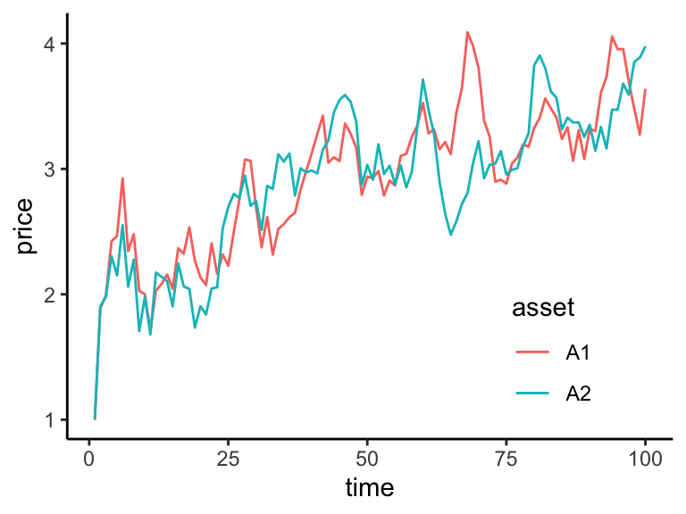

```r
tibble(time = 1:Tt, A1 = p[,1], A2 = p[,2]) |>
  pivot_longer(-time, names_to = "asset", values_to = "price") |>
  ggplot(aes(x = time, y = price, color = asset)) + geom_line() +
  theme_classic() +
  theme(legend.position = c(0.8,0.2))
```

### 2.2.5 A closer look

Now, what if we run several scenarios (simulations)?

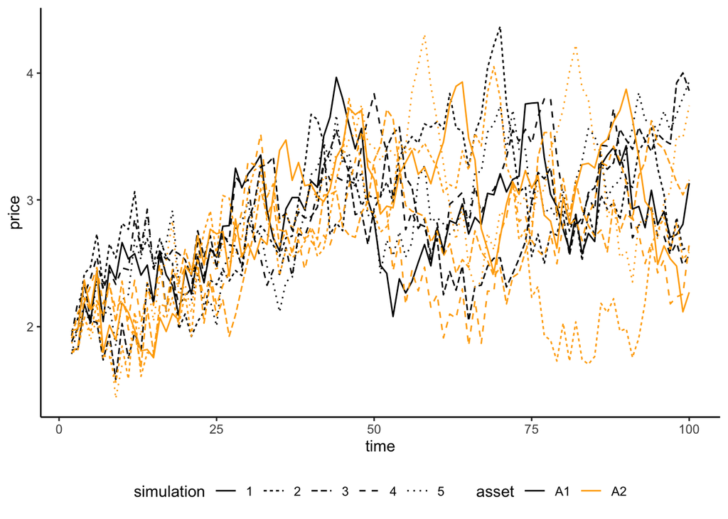

```r
source("plot_pr.R")
prices <- gen_price(r_f     = 0.02,           # Risk-free rate
                    R_f     = 1+0.02,          # Gross risk-free rate
                    sigma_d = 0.005,          # Volatility of dividends
                    cor_d   = 0.1,            # Correlation between dividends
                    sigma_s = 0.1,            # Volatility of supply shocks
                    cor_s   = 0.7,            # Correlation between supply shocks
                    theta_f = 2,              # Risk aversion for fundamentalists
                    theta_m = 1,              # Risk aversion for momentum traders
                    delta   = 0.8,            # Exp-weighted moving average param for means
                    lambda  = 0.9,            # Momentum trader covariance shrinkage
                    n_f     = 0.5,            # Proportion of fundamentalists on the market
                    n_m     = 1-0.5,          # Proportion of momentum traders
                    d_0     = c(0.02, 0.03),  # Starting point for dividends
                    s_0     = c(1,1),         # Starting point for supply
                    p_0     = c(1,1),         # Starting point for prices
                    E_0     = c(1,1),         # Starting point for expectations
                    Omega_0 = matrix(c(0.01, 0.005, 0.005, 0.01), nrow = 2),
                    Tt, n_sim)
prices |>
  pivot_longer(-c(time, simulation), names_to = "asset", values_to = "price") |>
  mutate(simulation = as.character(simulation)) |>
  ggplot(aes(x = time, y = price, color = asset, linetype = simulation)) + geom_line() +
  theme_classic() +
  theme(legend.position = "bottom") +
  scale_colour_manual(values = c("black", "#FFAA00"))
```

Looks rather realistic!

*Exercise*: change the code so that $n_f$ (and $n_m$) is a function of the past performance of the two agent types: $n_f$ increases when fundamentalists outperform. (**NOTE**: this is Section 4.2.5 in the original paper, and expressions are long…).

In a similar format (two agent types), we also point to [Extrapolation and bubbles](https://www.sciencedirect.com/science/article/abs/pii/S0304405X18301016).

## 2.3 HARK

There is a Python library called [**HARK**](https://github.com/econ-ark/HARK), with lengthy [documentation](https://docs.econ-ark.org/overview/ARKitecture.html). To use it in a quarto notebook, it needs to be installed.

```r
library(reticulate)
py_install("econ-ark")
```

We can then pursue with a simple example, which is explained in detail [here](https://github.com/econ-ark/HARK/blob/master/Documentation/ConsumptionSavingModels.pdf) and [also here](https://hark.readthedocs.io/en/latest/example_notebooks/Gentle-Intro-To-HARK.html).  
The module deals with optimal consumption under an assumption of perfect foresight for the agent.

```python
import matplotlib.pyplot as plt
import numpy as np
import HARK

from HARK.utilities import plot_funcs
from HARK.ConsumptionSaving.ConsIndShockModel import PerfForesightConsumerType

PF_params = {
    "CRRA": 2.5,           # Relative risk aversion
    "DiscFac": 0.96,       # Discount factor
    "Rfree": 1.03,         # Risk free interest factor
    "LivPrb": [0.98],      # Survival probability
    "PermGroFac": [1.01],  # Income growth factor
    "T_cycle": 1,
    "cycles": 0,
    "AgentCount": 10000,
}

# Create an instance of a Perfect Foresight agent with the above paramaters
PFexample = PerfForesightConsumerType(**PF_params)
```

Below, the $x$-axis is $m=M/P$, the ratio of market resources to permanent labor income. The $y$-axis is $c=C/P$, the ratio of consumption to income.  
The agent with zero money should be spending at a rate more than double the income. Some constraints are missing in the model…

```python
# Tell the agent to solve the problem
PFexample.solve()
# Retrieve the consumption function of the solution
PFexample.solution[0].cFunc
# Retrieve the solved value for human wealth normalized by permanent income
```

```
<HARK.interpolation.LinearInterp object at 0x178775f10>
```

```python
PFexample.solution[0].hNrm
```

```
50.49994992551661
```

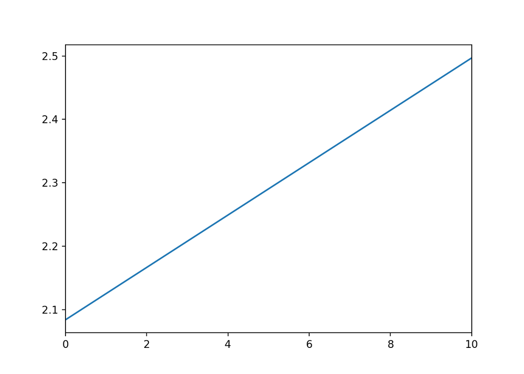

```python
mPlotTop = 10
plot_funcs(PFexample.solution[0].cFunc, 0.0, mPlotTop)
```

The coding environment is very rich and allows for **many extensions** (eg: adding income shocks, or focusing on [optimal portfolio choice](https://hark.readthedocs.io/en/latest/example_notebooks/ConsPortfolioModel.html)).

# 3 A “static” approach

## 3.1 Theory

This section follows [International asset pricing with heterogeneous agents: Estimation and inference](https://www.sciencedirect.com/science/article/abs/pii/S0927539823001263) which is inspired from [Asset Pricing with Countercyclical Household Consumption Risk](https://onlinelibrary.wiley.com/doi/full/10.1111/jofi.12471).

The starting point is the expression of the **stochastic discount factor** (SDF), which has a shape obtained from Epstein-Zin preferences:

$$M_{i,t+1}=\exp \left(\gamma_0 \log(\delta)+ \gamma_1 \Delta c_{i,t+1} +\gamma_3 r_{i,t+1} \right),$$

with $\Delta c$ being consumption growth and $r$ the (log) return on agents’ wealth portfolios. The index $i$ stands for some representative agent pertaining to country $i$. Furthermore, the dynamics of **aggregate** (world) consumption are
$$\Delta c_{t+1}=\mu_c+\sigma_c e_{t+1},$$
with $e_t$ being iid. In addition, as in [Asset Pricing with Countercyclical Household Consumption Risk](https://onlinelibrary.wiley.com/doi/full/10.1111/jofi.12471), we assume that agent $i$’s consumption is $c_{i,t}=\delta_{i,t}c_t$, where the share $\delta_{i,t}$ is expressed as:
$$\delta_{i,t}=\exp \left(\sum_{s=1}^t \underbrace{ \left(j_{i,s}^{1/2}\sigma \eta_{i,s}-j_{i,s}\sigma^2/2\right)}_{\text{common shock}}+ \underbrace{\left(\tilde{j}_{i,s}^{1/2}\tilde{\sigma} \tilde{\eta}_{i,s}-\tilde{j}_{i,s}\tilde{\sigma}^2/2\right)}_{\text{idiosyncratic shock}} \right), \tag{2}$$
where $\eta_{i,s}$ and $\tilde{\eta}_{i,s}$ are Gaussian variables and $j_{i,s}$ and $\tilde{j}_{i,s}$ are Poisson processes. The only difference between the two variable types is that $j_{i,s}$ depends on a common (random) state variable $x_s$ that characterizes the economy (e.g., a global business cycle, but no details given here), whereas $\tilde{j}_{i,s}$ depends on some fixed parameter. The Poisson variable sets the shock times and the Gaussian ones the shock magnitude. Equation 2 can be shown to be obtained upon equilibrium when assuming that the consumption growth of agents is independent of the consumption level (Appendix B in [Asset Pricing with Countercyclical Household Consumption Risk](https://onlinelibrary.wiley.com/doi/full/10.1111/jofi.12471)).

Taking the average of $M_{i,t+1}$ conditionally on the informational set $I_{t+1}$ containing $c_t$, $c_{t+1}$, $x_t$ and $x_{t+1}$ gives the following form
$$M_{t+1}=\mathbb{E}[M_{i,t+1}|I_{t+1}]=\exp \left(b_0 -b_1\Delta c_{t+1} - b_2x_{t+1}-b_3\Delta x_{t+1} \right)$$

The main issue is that the aggregate risk proxy $x_t$ is unobservable. To solve this problem, it is possible to define the country-specific relative consumption growth
$$g_{i,t}=\log\left(\frac{c_{i,t}/c_t}{c_{i,t-1}/c_{t-1}} \right)=\left(j_{i,s}^{1/2}\sigma \eta_{i,s}-j_{i,s}\sigma^2/2\right)+\left(\tilde{j}_{i,s}^{1/2}\tilde{\sigma} \tilde{\eta}_{i,s}-\tilde{j}_{i,s}\tilde{\sigma}^2/2\right).$$
Conditionally on $x_t$, the cross-sectional moments of $g_{i,t}$ depend on $\sigma$ and $\tilde{\sigma}$, but more importantly, linearly on the parameter $\tilde{x}$ and on $x_t$. Hence, reversely, we can express $x_t$ and linear combinations of these moments, which we write $\mu_t^{(k)}=\mathbb{E}[g_{i,t}^k|x_t]$. Hence, the factors $x_t$ and $\Delta x_t$ are replaced by $\mu_t^{(k)}$ and $\Delta \mu_t^{(k)}$ for $k=1,2,...$.

## 3.2 Empirics

We download data from the **World Bank**: GDP, consumption and stock market returns.

```r
library(WDI)
# country_list <- c("AF", "AR", "AT", "AU", "BE", "BR", "BY", "CA", "CD", "CL",
#                   "CM", "CN", "CO", "CZ", "DE", "DZ", "EG", "ES", "ET", "FR",
#                   "GB", "GH", "GR", "ID", "IL", "IN", "IQ", "IR", "IT", "JP",
#                   "KE", "KZ", "LY", "MA", "MG", "MM", "MX", "MY", "NG", "NP",
#                   "PH", "PK", "PL", "RU", "SA", "SD", "TD", "TH", "TR",
#                   "TW", "UG", "US", "UZ", "VE", "VN", "YE", "ZA")
wb_data <- WDI(                                        # World Bank data
    indicator = c("pop" = "SP.POP.TOTL",               # Population
                  "gdp" = "NY.GDP.MKTP.CD",            # Gross Domestic Product (GDP)
                  "consump" = "NE.CON.TOTL.CD",        # Final consump. expend. (constant LCU)
                  "gdp_growth" = "NY.GDP.MKTP.KD.ZG",  # Annual GDP growth
                  "stock_market" = "CM.MKT.INDX.ZG"),  # Local S&P index annual return (%)
    #country = country_list,                           # Zones: US, France, etc.
    extra = TRUE,
    start = 1960,
    end = 2021) |>
  filter(region != "Aggregates") |>                    # Remove continental aggregates
  arrange(country, year)                               # Sort neatly
wb_data |> head(6)
```

| country | iso2c | iso3c | year | status | lastupdated | pop | gdp | consump | gdp_growth | stock_market | region | capital | longitude | latitude | income | lending |
| --- | --- | --- | --- | --- | --- | --- | --- | --- | --- | --- | --- | --- | --- | --- | --- | --- |
| Afghanistan | AF | AFG | 1960 |  | 2023-12-18 | 8622466 | 537777811 | 466666656 | NA | NA | South Asia | Kabul | 69.1761 | 34.5228 | Low income | IDA |
| Afghanistan | AF | AFG | 1961 |  | 2023-12-18 | 8790140 | 548888896 | 477777738 | NA | NA | South Asia | Kabul | 69.1761 | 34.5228 | Low income | IDA |
| Afghanistan | AF | AFG | 1962 |  | 2023-12-18 | 8969047 | 546666678 | 466666656 | NA | NA | South Asia | Kabul | 69.1761 | 34.5228 | Low income | IDA |
| Afghanistan | AF | AFG | 1963 |  | 2023-12-18 | 9157465 | 751111191 | 702222244 | NA | NA | South Asia | Kabul | 69.1761 | 34.5228 | Low income | IDA |
| Afghanistan | AF | AFG | 1964 |  | 2023-12-18 | 9355514 | 800000044 | 762222182 | NA | NA | South Asia | Kabul | 69.1761 | 34.5228 | Low income | IDA |
| Afghanistan | AF | AFG | 1965 |  | 2023-12-18 | 9565147 | 1006666638 | 995555556 | NA | NA | South Asia | Kabul | 69.1761 | 34.5228 | Low income | IDA |

We compute the growth of relative consumption and consumption per capita.

```r
FM_data <- wb_data |>
  mutate(cons_per_cap = consump/pop) |>                                   # Consump per capita
  mutate(delta_c = cons_per_cap/lag(cons_per_cap) - 1, .by = country) |>  # Consump growth
  mutate(rel_cons = consump/sum(consump, na.rm = T), .by = year) |>       # Relative consumption
  mutate(g = rel_cons / lag(rel_cons) - 1, .by = country)
```

**NOTE**: cross-sectional moments/cumulants can be computed using weights such as population or total consumption. For simplicity, we will use simple (uniform) weights.

```r
country_list <- FM_data |>
  filter(is.finite(delta_c), is.finite(stock_market), is.finite(g)) |>
  group_by(country) |>
  count() |>
  filter(n > 19) |>
  pull(country)

country_list
```

```
 [1] "Argentina"            "Australia"            "Austria"
 [4] "Bahrain"              "Bangladesh"           "Belgium"
 [7] "Botswana"             "Brazil"               "Bulgaria"
[10] "Canada"               "Chile"                "China"
[13] "Colombia"             "Cote d'Ivoire"        "Croatia"
[16] "Denmark"              "Ecuador"              "Egypt, Arab Rep."
[19] "Estonia"              "Finland"              "France"
[22] "Germany"              "Ghana"                "Greece"
[25] "Hong Kong SAR, China" "Hungary"              "India"
[28] "Indonesia"            "Ireland"              "Israel"
[31] "Italy"                "Jamaica"              "Japan"
[34] "Jordan"               "Kenya"                "Korea, Rep."
[37] "Latvia"               "Lebanon"              "Lithuania"
[40] "Malaysia"             "Mauritius"            "Mexico"
[43] "Morocco"              "Namibia"              "Netherlands"
[46] "New Zealand"          "Norway"               "Oman"
[49] "Pakistan"             "Peru"                 "Philippines"
[52] "Poland"               "Portugal"             "Romania"
[55] "Russian Federation"   "Saudi Arabia"         "Singapore"
[58] "Slovak Republic"      "Slovenia"             "South Africa"
[61] "Spain"                "Sweden"               "Switzerland"
[64] "Thailand"             "Tunisia"              "Turkiye"
[67] "Ukraine"              "United Kingdom"       "United States"
```

Below, the factors are computed using *all* countries, which is not the case in the original paper.

```r
FM_data <- FM_data |>
  filter(country %in% country_list) |>
  mutate(Delta_c = mean(delta_c, na.rm = T), .by = year) |>   # Delta c_t
  mutate(x_t_1 = mean(g, na.rm = T), .by = year) |>
  mutate(x_t_2 = mean(g^2, na.rm = T), .by = year) |>
  mutate(x_t_3 = mean(g^3, na.rm = T)/sd(g, na.rm = T)^3, .by = year) |>
  mutate(x_t_4 = (mean(g^4, na.rm = T) - 3*x_t_2^2)/sd(g, na.rm = T)^4, .by = year) |>
  mutate(D_x_t = x_t_1-lag(x_t_1), .by = country) |>
  na.omit()
```

We also fetch a risk free rate proxy (retrieved from the [data portfal of the FRED of Saint Louis](https://fred.stlouisfed.org)). This requires an authentication key, which is why the full code is omitted below and the data is stored on a private repo. We then join the data and compute the excess returns.

```r
RF <- read.csv("https://raw.githubusercontent.com/shokru/coqueret.github.io/master/files/misc/risk_free.csv")
RF <-  RF |>
  mutate(date = as.Date(date),
         year = year(date)) |>
  summarise(rf = mean(value/100), .by = year)
FM_data <- FM_data |>
  left_join(RF, by = "year") |>
  mutate(r = stock_market/100 - rf)
```

Equipped with these factors, we can now proceed to **Fama-MacBeth regressions** to see if they do a good job at explaining the returns of the cross-section of countries. We use the {broom} package to automate the process. First, the first pass.

```r
betas <- FM_data |>
  group_by(country) |>
  group_modify(.f = ~ broom::tidy(glm(r ~ Delta_c + x_t_1 + x_t_2 + x_t_3 + x_t_4 + D_x_t,
                                      data = .x))) |>
  select(country, term, estimate) |>
  pivot_wider(names_from = "term", values_from = "estimate")
betas |> head(9)
```

| country | (Intercept) | Delta_c | x_t_1 | x_t_2 | x_t_3 | x_t_4 | D_x_t |
| --- | --- | --- | --- | --- | --- | --- | --- |
| Argentina | 0.1490167 | -1.9619569 | 4.6782459 | 9.0180435 | 0.0354678 | -0.0112520 | 1.4074594 |
| Australia | -0.0229156 | -0.3510414 | 0.7114716 | 7.9382777 | 0.0258168 | -0.0023461 | -2.4581222 |
| Austria | 0.0172164 | 0.0273413 | 0.7595919 | -0.4715833 | 0.0098007 | 0.0024488 | -1.1350423 |
| Bahrain | 0.1081724 | 1.3950145 | -1.1143088 | -12.5310750 | 0.0061923 | -0.0006078 | 0.6098254 |
| Bangladesh | -0.0322910 | 3.1107385 | -3.3007345 | -1.8170300 | 0.0217112 | -0.0047065 | -0.7156673 |
| Belgium | -0.0142282 | -1.0412954 | 2.7439090 | 7.2758187 | 0.0185407 | -0.0009646 | -3.5035496 |
| Botswana | -0.1287554 | -1.6165045 | 6.3151849 | 19.7146478 | 0.0257722 | 0.0086231 | -3.3293966 |
| Brazil | -0.0797492 | 1.5407605 | -3.9524087 | 15.3984894 | 0.1232646 | -0.0116877 | -4.6488464 |
| Bulgaria | -0.2565878 | 1.9527342 | 7.5366955 | 19.2776722 | -0.0630090 | 0.0056852 | 5.0313747 |

Then, the second pass.

```r
premia <- FM_data |>
  select(country, year, r) |>
  left_join(betas, by = "country") |>
  group_by(year) |>
  group_modify(.f = ~ broom::tidy(glm(r ~ Delta_c + x_t_1 + x_t_2 + x_t_3 + x_t_4 + D_x_t,
                                      data = .x))) |>
  select(year, term, estimate) |>
  pivot_wider(names_from = "term", values_from = "estimate")
```

We then perform simple *t*-tests for the **mean** of the loadings.

```r
test <- function(v){
  t.test(v)$statistic
}

apply(premia[,-1], 2, mean) |> round(3)
```

```
(Intercept)     Delta_c       x_t_1       x_t_2       x_t_3       x_t_4
      0.049       0.003       0.001       0.003       0.197      -0.968
      D_x_t
      0.004
```

```r
apply(premia[,-1], 2, test) |> round(3)
```

```
(Intercept)     Delta_c       x_t_1       x_t_2       x_t_3       x_t_4
      1.630       0.145       0.135       1.522       0.473      -0.640
      D_x_t
      0.610
```

The $t$-statistics are quite low and do not incite to reject the null of zero coefficients.  
Hence, the results are not great…

# 4 Another look at supply and demand

This section is dedicated to a theoretical exposé of the paper [A Demand System Approach to Asset Pricing](https://www.journals.uchicago.edu/doi/abs/10.1086/701683?mobileUi=0&) by Koijen & Yogo.

## 4.1 From utility to characteristics

One of the contributions of the paper is the following. Usually, investors are expected to maximize their utility via the return of their portfolio (here we exclude consumption consideration). Basically, they solve
$$\underset{w}{\max} \ \mathbb{E}[u(1+w'r)],$$
where $r$ is the vector of returns of the assets. But in practice, professionals balance risk and return via **estimations** of expected returns and covariance matrices. However, more and more, investors rely on firm characteristics to determine their investment choices.

In the paper of Koijen & Yogo, the authors reconcile the two approaches by assuming that **characteristics can be drivers of performance**. We present their 2 main results below.

There are $I$ investors who can invest in $N$ assets. We write $P_{t,n}$, $D_{t,n}$ and $S_{t,n}$ for their time$t$ price, dividend per share and number of shares outstanding. The total market capitalization (market equity) is equal to $ME_{t,n}=S_{t,n}P_{t,n}$. Moreover, $R_{t,n}=(P_{t,n}+D_{t,n})/P_{t-1,n}$ is the gross total return. Lowercase letters denote **logarithms**: $p_{t,n}$, $d_{t,n}$, $s_{t,n}$ and $r_{t,n}$, which are stacked using bold notations: $\textbf{p}_t$ is the $N$-dimensional vector of all prices at time $t$ ($me_{t,n}=\log(s_{t,n})+\log{p_{t,n}}$). There is also an **outside asset**, which represents the wealth outside the scope of the model (or the study).

Firms are also characterized by $K$ indicators (e.g., accounting ratios, risk measures), $x_{t,n}^{(k)}$ and, by convention, the last characteristic is a constant, i.e., $x_{t,n}^{(K)}=1$. Also, the first characteristic is the firm size, i.e., $me$ (market equity).

In the paper, investors seek to solve
$$\underset{w_{t,i}}{\max} \ \mathbb{E}_{t,i}[\log(A_{T,i})],$$
where $A_{T,i}$ is **terminal wealth** with dynamics
$$A_{t+1,i}=A_{t,i}(\textbf{w}_{t+1,i}'\textbf{R}_{t+1}-R_{t+1,0}(1-\textbf{w}_{t+1,i}'\textbf{1})),$$
i.e., there is a portion $1-\textbf{w}_{t+1,i}'\textbf{1}>0$ that is sent to the outside asset. Moreover, all weights must be positive (no shortsale constraint). The expectation is conditional on time and on investors’ beliefs.

The crucial assumption is the following. The covariance matrices of excess returns with respect to the outside asset all have the form

$$\boldsymbol{\Sigma}_{t,i}=\boldsymbol{\Gamma}_{t,i}\boldsymbol{\Gamma}_{t,i}'+\gamma_{t,i} \textbf{I},$$
where $\boldsymbol{\Gamma}_{t,i}$ are vectors whose elements are **polynomial function** of $\textbf{x}_{t,n}$ (for the $n^{th}$ element). The same holds for expected returns, which also depend on a non-linear combination of the characteristics.

**Important**

Under this assumption, the optimal weights can be expressed as
$$\frac{w_{t,i,n}}{w_{t,i,0}}=\exp \left(\beta_{t,i,0} me_{t,n}+\sum_{k=1}^{K-1} \beta_{t,i,k}x^{(k)}_{t,n} + \beta_{t,i,K} \right)\epsilon_{t,n,i},$$
where $\epsilon_{t,n,i}$ is called *latent demand*, i.e., the demand that is not explained by the observed characteristics.[^4]

$\rightarrow$ **bottom line**: portfolios depend on the $\beta_{t,i,k}$, which characterize the preference of investors with respect to firms’ attributes. This allows to bypass the need to optimize utility! And in practice, this is how many (most) money managers proceed (often modulo some form of mean-variance optimization).

## 4.2 Equilibrium and demands

The **equilibrium** is reached from market clearing (supply = demand):

$$ME_{t,n}=\sum_{i=1}^IA_{t,i}w_{t,i,n},$$
i.e., market capitalization is equal to the sum of the amount invested in the firm across all investors. Taking the logarithm, this gives, omitting time indices
$$\textbf{p}=\textbf{me}-\textbf{s}=\log \left(\sum_{i=1}^IA_i w_i(\textbf{p})\right)-\textbf{s}=\textbf{f}(\textbf{p}),$$
because indeed, the weights depend on $me$, hence on prices. An important results is the following.

**Important**

If, for all investors, $\beta_{t,i,0}<1$ and if, for all assets $n$, there is at least one investor with $\beta_{t,in}\in(-1,1)$, then $\textbf{f}(\textbf{p})$ has a unique fixed point in $\mathbb{R}^N$.

The solution is found numerically via Newton’s method with a simplified Jacobian matrix to ease computations.

# 5 HANKs & co.

## 5.1 Theory

Since the 2010 decade, a new family of models has emerged: **Heterogeneous Agent New Keynesian** (HANK) models. The problem is that each paper has its own way to define heterogeneity. And own focus on variable of interest; for example:

- **monetary policy**:
  1. [Monetary Policy According to HANK](https://www.aeaweb.org/articles?id=10.1257/aer.20160042),
  2. [Optimal Monetary Policy According to HANK](https://www.aeaweb.org/articles?id=10.1257/aer.20200239) +
  3. **THANK** (tractable HANK)
- **Income risk**: [Understanding HANK- Insights from a PRANK](https://onlinelibrary.wiley.com/doi/abs/10.3982/ECTA16409)

## 5.2 Practice

HAMs are often complex tools. Recently, researchers have sought to leverage modern computation techniques to numerically solve economic equilibria. They are not necessarily related to finance or asset pricing, or even to HANKs strictly speaking, but interesting nonetheless!

- **Deep learning**:
  1. [DeepHAM](https://arxiv.org/abs/2112.14377),
  2. [Deep Learning for Individual Heterogeneity: An Automatic Inference Framework](https://arxiv.org/abs/2010.14694)
- **Perturbation**:
  1. [A method for solving and estimating heterogeneous agent macro models](https://onlinelibrary.wiley.com/doi/full/10.3982/QE740)
  2. [Solving discrete time heterogeneous agent models with aggregate risk and many idiosyncratic states by perturbation](https://onlinelibrary.wiley.com/doi/full/10.3982/QE1243)

## Footnotes

[^1]: This is a first strong assumption.
[^2]: Other assumption: wealth can be negative! Though with negligible probability if parameters are reasonable.
[^3]: Here we slightly depart from the original paper.
[^4]: In fact, this component is by far the most important to explain demands (upon estimation). Characteristics do not account for much…